# Two Variables: Qualitative

Author

Lorenzo D. Babato

Published

November 14, 2026

# The Data

```r
# install packages: install.packages("package")
# load packages
library(tidyverse)
library(knitr)
library(gtsummary)
library(ggstatsplot)
library(downlit)
library(broom)
library(car)
library(here)
```

```r
df <- read_csv(here("data", "my_dataset_enso.csv"))

df <- df |>
  mutate(
    # 1. First Ordinal Variable: Academic Satisfaction
    Academic_Satisfaction = factor(
      Academic_Satisfaction,
      levels = c("Low_satisfaction", "Moderate_Satisfaction", "High_Satisfaction"),
      ordered = TRUE
    ),

    # 2. Second Ordinal Variable: Sleep Duration
    Sleep_Duration = factor(
      Sleep_Duration,
      levels = c("Less_than_6_hours", "6_to_8_hours", "More_than_8_hours"),
      ordered = TRUE
    )
  ) |>
  select(
    Academic_Satisfaction,
    Sleep_Duration
  )
```

## NVSU_Student_Survey

The ‘NVSU_Student_Survey’ data set is a data frame with 68 rows and 2 variables.

The first 6 rows of the data set are shown in Table 1

```r
df |> # call the data
  head() |> # get the first six rows of the data
  kable(
    col.names = c("Academic Satisfaction", "Duration of Sleep")
  ) # create a table
```

Table 1: The first 6 observations of the data set.

| Academic Satisfaction | Duration of Sleep |
| --- | --- |
| Low_satisfaction | Less_than_6_hours |
| Low_satisfaction | Less_than_6_hours |
| Low_satisfaction | Less_than_6_hours |
| Low_satisfaction | Less_than_6_hours |
| Low_satisfaction | Less_than_6_hours |
| Low_satisfaction | Less_than_6_hours |

## Descriptive Statistics

```r
#| label: tbl-summary
#| tbl-cap: "Summary statistics of `Academic_Satisfaction` when grouped according to `Sleep_Duration`."
#| message: false

df |>

#  tbl_summary(
#    by = Academic_Satisfaction,
#    include = Sleep_Duration
    tbl_cross(
      row = Academic_Satisfaction,
      col = Sleep_Duration,
      percent = "column",
      margin = c("row", "column"),
      label = list(
        Academic_Satisfaction ~ "Academic Satisfaction",
        Sleep_Duration ~ "Duration of Sleep"
      )
  )
```

|  | Duration of Sleep Less_than_6_hours | Duration of Sleep 6_to_8_hours | Duration of Sleep More_than_8_hours | Total |  |
| --- | --- | --- | --- | --- | --- |
| Academic Satisfaction |  |  |  |  |  |
| Low_satisfaction | 11 (39%) | 0 (0%) | 0 (0%) | 11 (16%) |  |
| Moderate_Satisfaction | 17 (61%) | 26 (74%) | 0 (0%) | 43 (63%) |  |
| High_Satisfaction | 0 (0%) | 9 (26%) | 5 (100%) | 14 (21%) |  |
| Total | 28 (100%) | 35 (100%) | 5 (100%) | 68 (100%) |  |

# Hypothesis Testing

## Research Question

Does the students’ duration of sleep affect their academic satisfaction?

## Hypothesis and Test Statistics

- $H_0:p_{Sleep\,Duration}-p_{Academic\,Satisfaction}=0$; Students’ duration of sleep and their academic satisfaction are independent (no association).
- $H_a:p_{Sleep\,Duration}-p_{Academic\,Satisfaction}\ne0$; Students’ duration of sleep and their academic satisfaction are dependent (associated).
- Significance level, $\alpha=5\%\,\text{or p-value}\,\le\,.05$.
- **Pearson’s** $\chi^2$-test of independence
- Independence.
- Expected counts: Not all expected counts are $\ge 5$ (multiple cells fall below 5; see Table 2).

```r
# Create contingency table using df
observed <- table(df$Sleep_Duration, df$Academic_Satisfaction)

# Perform chi-squared test
chi_test <- chisq.test(observed)

# Extract the expected counts
expected <- chi_test$expected

# View expected counts
expected |>
  as_tibble() |>
  mutate(
    " " = c("Less_than_6_hours", "6_to_8_hours", "More_than_8_hours")
  ) |>
  relocate(" ", .before = 1) |>
  mutate(across(where(is.numeric), ~ round(.x, 2))) |>
  kable()
#as.data.frame(chi_test$expected) |>
#  tibble::rownames_to_column(var = "Sleep Duration") |>
#  mutate(across(where(is.numeric), ~ round(.x, 2))) |>
#  kable()
```

Table 2: Expected counts.

|  | Low_satisfaction | Moderate_Satisfaction | High_Satisfaction |
| --- | --- | --- | --- |
| Less_than_6_hours | 4.53 | 17.71 | 5.76 |
| 6_to_8_hours | 5.66 | 22.13 | 7.21 |
| More_than_8_hours | 0.81 | 3.16 | 1.03 |

## Results and Interpretation

The bar chart and test statistics are shown on Figure 1.

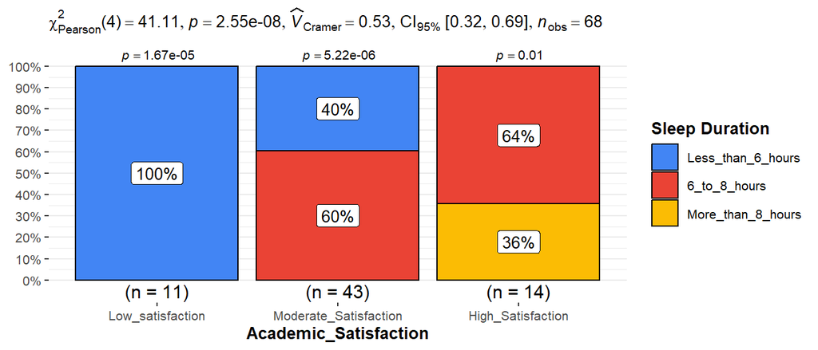

Figure 1: Bar chart and test statistics.

```r
ggbarstats(
  data = df,
  x = Sleep_Duration,
  y = Academic_Satisfaction,
  type="nonparametric",
  bf.message = FALSE,
  legend.title = "Sleep Duration"
)
```

Based on the bar chart and the $p$-value being less than 5% ($p < 0.001$), we reject the null hypothesis. There is strong evidence that students’ duration of sleep affects their academic satisfaction.